# Trial Generation for fMRI version 1 - session 2

Joern Alexander Quent

22/09/2022

# Description

This is used to generate the trials for the fMRI version 1 - session 2. This includes the following components & parameters:

# General task parameters

```r
# Speed rotation
speedForward  <- 10 # vm/s
rotationSpeed <- 50 # degrees/s

# Number of times each object is presented
numberPerObject <- 3

# Timing
cuePeriod      <- rep(2, numberPerObject) # seconds
delayPeriods   <- seq(from = 1, to = 2, length.out = numberPerObject) # seconds
ITIPeriods     <- seq(from = 1, to = 2, length.out = numberPerObject) # seconds
```

# Available objects

| Object | Number | Version |
| --- | --- | --- |
| Drum | 7 | Desert |
| Basketball | 2 | Desert |
| Pineapple | 12 | Desert |
| Dice | 5 | Desert |
| Cake | 3 | Desert |
| Lamp | 10 | Desert |
| Barrel | 1 | Grassy |
| Football | 8 | Grassy |
| Pawn | 11 | Grassy |
| Traffic cone | 4 | Grassy |
| Donut | 6 | Grassy |
| Vase | 13 | Grassy |
| Gift | 9 | Control |
| Teddy | 14 | Practice |

# Needed column for the .csv file

The .csv files needs entries the following columns:

- *trial_num* = Number of the trial (This will ensure that thee trials will be presented in the right order)
- *block_num* = Number of the block (needed for UXF).
- *targets* = The target given as the object number from 1 - 13 (see below how these numbers correspond to the object names).
- *start_x* = Start location of the player.
- *start_z* = Start location of the player.
- *start_yRotation* = Start rotation of the player.
- *object_x* = Object location of the target. With the exception of control trials, this must be the same for all trials with the same target.
- *object_z* = Object location of the target. With the exception of control trials, this must be the same for all trials with the same target.
- *cue* = Period the cue is presented in seconds.
- *delay* = Delay period after the cue was presented in seconds.
- *ITI* = ITI in seconds.
- *trialType* = Trial type i.e. encoding, retrieval or control trials (last one using the gift as the object).
- *speedForward* = Forward speed in vm/s.
- *rotationSpeed* = Rotation speed in degrees/s.
- *start_centrality* If start location is less than half the radius away from the centre, then it is central otherwise periphery. This not used by the unity.
- *perfectAngle* = The movement angle that leads from the start point to the target.
- *messageToDisplay* = Integer indicating whether a messages should be displayed after the trial (yes if >= 0, no if -1). Numbers above -1 are used as the index of the message from the list.

# Pre-scanning practice

In order to make things a bit easier, the practice trials are not chosen algorithmically but were simply manually defined.

```r
# Seed for practice
set.seed(20220922+5)

# Randomly choose object locations
objLoc <- data.frame(x = c(-25, 5, 20),
                     z = c(25, -23, -2),
                     object = as.factor(1:3))

# Practice
trialOrder <- data.frame(object = c(sample(rep(1:3, each = 2)), sample(rep(1:3, each = 2)), 1, 2))


# Get only the main task object
practice_objects <- tab1[tab1$Version == "Desert", ]
practice_objects <- practice_objects[1:3, ] # Only the first three

# Assign the temporary label from the trial order to it
practice_objects$tempNum <- 1:3

# Quickly loop through trialOrder
trialOrder$targets     <- NA
trialOrder$targetNames <- NA
trialOrder$x           <- NA
trialOrder$z           <- NA
for(i in 1:nrow(trialOrder)){
  # Object name
  trialOrder$targets[i]     <- practice_objects$Number[as.numeric(trialOrder[i, 'object'])]
  trialOrder$targetNames[i] <- practice_objects$Object[as.numeric(trialOrder[i, 'object'])]

  # Object location
  trialOrder$x[i] <- objLoc$x[as.numeric(trialOrder[i, 'object'])]
  trialOrder$z[i] <- objLoc$z[as.numeric(trialOrder[i, 'object'])]
}

# Add random start location
trialOrder$start_x <- c(-12, 25, 12.5, -25, 0, 13.5, 6, 12.5, -12.5, 0 , 7,-12.5, -25, 12)
trialOrder$start_z <- c(30, 0, 5, -12.5, 30, 23, 27, 24, 2.5, 12.5 , 7,-30, 14, 7)

# Perfect angles
trialOrder$perfectAngle <- NA

# Add trial type
trialOrder$trialType <- c(rep("encoding", 6), rep("retrieval", 6), rep("control", 2))

# Loop through each trial
for(i in 1:nrow(trialOrder)){
  # Step 1 get points
  x <- trialOrder$x[i] - trialOrder$start_x[i]
  z <- trialOrder$z[i] - trialOrder$start_z[i]

  # Calculate angle
  trialOrder$perfectAngle[i] <- getAngleInDegreesFromPoint(x, z)
}
```

```r
# Adding to one DF
practice <- data.frame(trial_num = 1:nrow(trialOrder),
                       block_num = 1,
                       targets = trialOrder$targets,
                       targetNames= trialOrder$targetNames,
                       start_x = trialOrder$start_x,
                       start_z = trialOrder$start_z,
                       object_x = trialOrder$x,
                       object_z = trialOrder$z,
                       cue = c(sample(rep(cuePeriod, each = 4)), 2, 2),
                       delay = c(sample(rep(delayPeriods, each = 4)), 1.5, 1.5),
                       ITI = c(sample(rep(ITIPeriods, each = 4)), 1.5, 1.5),
                       trialType = trialOrder$trialType,
                       speedForward = speedForward,
                       rotationSpeed = rotationSpeed,
                       perfectAngle = trialOrder$perfectAngle,
                       messageToDisplay = -1)

# Sample start locations from uniform distribution
practice$start_yRotation <- runif(n = nrow(practice), min = 0, max = 360)

# After plotting put in the correct name for control trial
practice$targets[practice$trialType == 'control'] <- 9
practice$targetNames[practice$trialType == 'control'] <- "Gift"

# Add the messages
practice[6, 'messageToDisplay'] <- 0 # Between retrieval and encoding
practice[12, 'messageToDisplay'] <- 1 # Before control trials

# Write .csv file
write.csv(x = practice, file = 'inputFiles/1_practice/practice_fMRI_version1_session2.csv', quote = FALSE, row.names = FALSE)
```

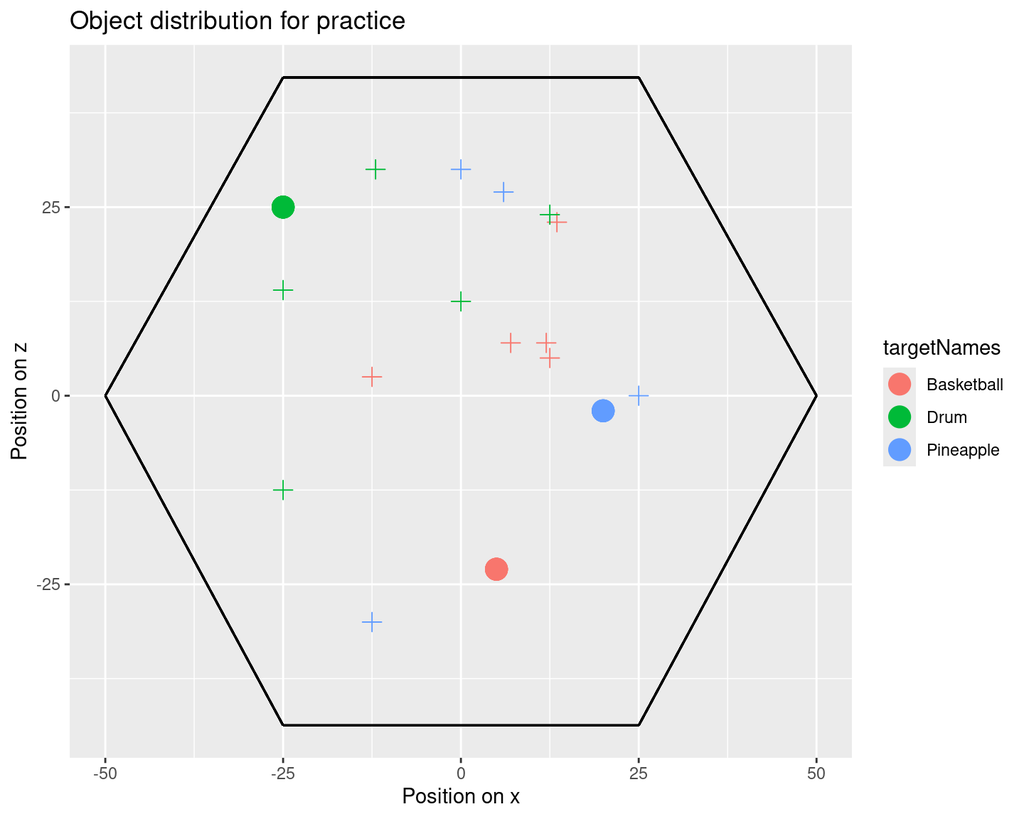

```r
ggplot(trialOrder) +
  geom_point(aes(x = x, y = z, colour = targetNames), size = 5) +
  geom_point(aes(x = start_x, y = start_z, colour = targetNames), size = 3, shape = 3) +
  # Border of the hexagon
  geom_segment(aes(x = 25, y = 42.2, xend = 50, yend = 0)) +
  geom_segment(aes(x = 50, y = 0, xend = 25, yend = -43.7)) +
  geom_segment(aes(x = 25, y =-43.7, xend = -25, yend = -43.7)) +
  geom_segment(aes(x = -25, y =-43.7, xend = -50, yend = 0)) +
  geom_segment(aes(x = -50, y =0, xend = -25, yend = 42.2)) +
  geom_segment(aes(x = -25, y = 42.2, xend = 25, yend = 42.2)) +
  # Labels
  labs(title = "Object distribution for practice", x = "Position on x", y = "Position on z")
```

Note the gifts are overlapping with the other two objects, which is why they are not visible.

# fMRI trial

The following algorithm was used to create the object locations:

> The object locations were randomly chosen with the following constraints: they had to be at least 25 vm from the edge of the environment, at least 10 vm from the centre and at least 10 vm away from the nearest other object.

```r
# Set the seed
set.seed(20220516 + 8)

# Re-run
rerun <- TRUE

# Constraints & parameters
obj2edge   <- 25
obj2centre <- 10
obj2obj    <- 10
diameter   <- 180
numObjects <- 6
centre     <- data.frame(x = 0, z = 0)
steps      <- 1

# Draw circle for the edge
edge   <- circleFun(c(0, 0), diameter, npoints = 1000)
edge$z <- edge$y # Rename to avoid error that columns do not match
edge$y <- NULL

# Get min & max for uniform distribution
minValue = -(diameter/2 - obj2edge)
maxValue = (diameter/2 - obj2edge)
# Because of the obj2edge constraint I don't even need to cover the full range of the environment

# Constraint function
isNotValid <- function(objLoc){
  # Object 2 edge constraint
  con1 <- c()
  for(i in 1:numObjects){
    # Temp bind
    tempBind <- rbind(objLoc[i, ], edge)

    # Remove row names
    row.names(tempBind) <- NULL

    # Calculate distances
    tempDistances <- as.matrix(dist(tempBind))


    con1[i] <- any(tempDistances[1, 2:nrow(tempDistances)] <= obj2edge)
  }
  # Aggregate with any
  con1 <- any(con1)

  # Object 2 centre constraint (also check that it is not outside the circle)
  tempDistances <- as.matrix(dist(rbind(centre, objLoc)))
  con2 <- any(tempDistances[1, 2:nrow(tempDistances)] <= obj2centre | tempDistances[1, 2:nrow(tempDistances)] > diameter/2)

  # Object 2 object constraint
  con3 <- any(dist(objLoc) <= obj2obj)



  return(any(con1, con2, con3))
}

# Run algorithm
# Randomly choose object locations
objLoc <- data.frame(x = runif(numObjects, min = minValue, max = maxValue),
                     z = runif(numObjects, min = minValue, max = maxValue))

# Check constraints
while(isNotValid(objLoc)){
  # Sample again
  objLoc <- data.frame(x = runif(numObjects, min = minValue, max = maxValue),
                       z = runif(numObjects, min = minValue, max = maxValue))

  # Count steps
  steps = steps + 1
}

# Add object number to objLoc
objLoc$object <- 1:6

# Save
save.image("OLM_startlocation_fMRI_version1_layout3.RData")
```

# Random starting locations

To run this, the algorithm from above is re-purposed to select the starting locations but first I create the trial order. As an added constraint, we don’t want the same object to appear twice in a row.

```r
# Seed
set.seed(20220517 + 8)

# Function to sample the timing variables
timing_sample <- function(df, cuePeriod, delayPeriods, ITIPeriods){
  # Get number of rows
  numRows <- nrow(df)

  # Add values
  df$cuePeriod <- sample(rep(cuePeriod, numRows/length(cuePeriod)))
  df$delayPeriods <- sample(rep(delayPeriods, numRows/length(delayPeriods)))
  df$ITIPeriods <- sample(rep(ITIPeriods, numRows/length(ITIPeriods)))

  return(df)
}

# Generate trial order function & add timing variables
gen_trialOrder <- function(objLoc){
  # Sample run 1
  run1 <- objLoc[sample(rep(1:6, each = numberPerObject)),]
  run1 <- timing_sample(run1, cuePeriod, delayPeriods, ITIPeriods)
  # Check if there are repetitions and if there are repeat part with repetition
  while(max(rle(run1$object)$length) > 1){
    # Generate trial order
    run1 <- objLoc[sample(rep(1:6, each = numberPerObject)),]
    run1 <- timing_sample(run1, cuePeriod, delayPeriods, ITIPeriods)
  }

  # For run 2 the sampling has to be done twice because this block/run is split between retrieval and control
  # Check if there are repetitions and if there are repeat part with repetition
  tempRun2_control   <- objLoc[sample(rep(1:6, each = numberPerObject)),]
  tempRun2_retrieval <- objLoc[sample(rep(1:6, each = numberPerObject)),]
  tempRun2_control   <- timing_sample(tempRun2_control, cuePeriod, delayPeriods, ITIPeriods)
  tempRun2_retrieval <- timing_sample(tempRun2_retrieval, cuePeriod, delayPeriods, ITIPeriods)
  run2               <- rbind(tempRun2_retrieval[1:((numberPerObject*numObjects)/2), ],
                              tempRun2_control[1:((numberPerObject*numObjects)/2), ],
                              tempRun2_retrieval[(((numberPerObject*numObjects)/2)+1):(numberPerObject*numObjects), ],
                              tempRun2_control[(((numberPerObject*numObjects)/2)+1):(numberPerObject*numObjects), ])
  while(max(rle(run2$object)$length) > 1){
    # Generate trial order
    tempRun2_control   <- objLoc[sample(rep(1:6, each = numberPerObject)),]
    tempRun2_retrieval <- objLoc[sample(rep(1:6, each = numberPerObject)),]
    tempRun2_control   <- timing_sample(tempRun2_control, cuePeriod, delayPeriods, ITIPeriods)
    tempRun2_retrieval <- timing_sample(tempRun2_retrieval, cuePeriod, delayPeriods, ITIPeriods)
    run2               <- rbind(tempRun2_retrieval[1:((numberPerObject*numObjects)/2), ],
                                tempRun2_control[1:((numberPerObject*numObjects)/2), ],
                                tempRun2_retrieval[(((numberPerObject*numObjects)/2)+1):(numberPerObject*numObjects), ],
                                tempRun2_control[(((numberPerObject*numObjects)/2)+1):(numberPerObject*numObjects), ])
  }

  # Sample run 3
  run3 <- objLoc[sample(rep(1:6, each = numberPerObject)),]
  run3   <- timing_sample(run3, cuePeriod, delayPeriods, ITIPeriods)
  # Check if there are repetitions and if there are repeat part with repetition
  while(max(rle(run3$object)$length) > 1){
    # Generate trial order
    run3 <- objLoc[sample(rep(1:6, each = numberPerObject)),]
    run3   <- timing_sample(run3, cuePeriod, delayPeriods, ITIPeriods)
  }

  # For run 4 the sampling has to be done twice because this block/run is split between retrieval and control
  # Check if there are repetitions and if there are repeat part with repetition
  tempRun4_control   <- objLoc[sample(rep(1:6, each = numberPerObject)),]
  tempRun4_retrieval <- objLoc[sample(rep(1:6, each = numberPerObject)),]
  tempRun4_control   <- timing_sample(tempRun4_control, cuePeriod, delayPeriods, ITIPeriods)
  tempRun4_retrieval <- timing_sample(tempRun4_retrieval, cuePeriod, delayPeriods, ITIPeriods)
  run4               <- rbind(tempRun4_retrieval[1:((numberPerObject*numObjects)/2), ],
                              tempRun4_control[1:((numberPerObject*numObjects)/2), ],
                              tempRun4_retrieval[(((numberPerObject*numObjects)/2)+1):(numberPerObject*numObjects), ],
                              tempRun4_control[(((numberPerObject*numObjects)/2)+1):(numberPerObject*numObjects), ])
  while(max(rle(run4$object)$length) > 1){
    # Generate trial order
    tempRun4_control   <- objLoc[sample(rep(1:6, each = numberPerObject)),]
    tempRun4_retrieval <- objLoc[sample(rep(1:6, each = numberPerObject)),]
    tempRun4_control   <- timing_sample(tempRun4_control, cuePeriod, delayPeriods, ITIPeriods)
    tempRun4_retrieval <- timing_sample(tempRun4_retrieval, cuePeriod, delayPeriods, ITIPeriods)
    run4               <- rbind(tempRun4_retrieval[1:((numberPerObject*numObjects)/2), ],
                                tempRun4_control[1:((numberPerObject*numObjects)/2), ],
                                tempRun4_retrieval[(((numberPerObject*numObjects)/2)+1):(numberPerObject*numObjects), ],
                                tempRun4_control[(((numberPerObject*numObjects)/2)+1):(numberPerObject*numObjects), ])
  }

  # Bind to 1 DF
  trialOrder <- rbind(run1, run2, run3, run4)

  # Check if no repetitions across runs/blocks
  if(max(rle(trialOrder$object)$length) > 1){
    trialOrder <- gen_trialOrder(objLoc)
  }

  # Return trial order
  return(trialOrder)
}

# Sample once
trialOrder <- gen_trialOrder(objLoc)
row.names(trialOrder) <- NULL

#### Add the correct object names
# Get only the main task object
mainTask_objects <- tab1[tab1$Version == "Grassy",]

# Assign the temporary label from the trial order to it
mainTask_objects$tempNum <- 1:numObjects

# Quickly loop through trialOrder
trialOrder$targets     <- NA
trialOrder$targetNames <- NA
for(i in 1:nrow(trialOrder)){
  trialOrder$targets[i]     <- mainTask_objects$Number[as.numeric(trialOrder[i, 'object'])]
  trialOrder$targetNames[i] <- mainTask_objects$Object[as.numeric(trialOrder[i, 'object'])]
}

# Add auxiliary information
trialOrder$trial_num <- 1:nrow(trialOrder)
trialOrder$block_num <- rep(1:4, times = c((numberPerObject*numObjects),
                                           (numberPerObject*numObjects)*2,
                                           (numberPerObject*numObjects),
                                           (numberPerObject*numObjects)*2))
trialOrder$trialType <- rep(c('encoding',
                              'retrieval',
                              'control',
                              'retrieval',
                              'control',
                              'encoding',
                              'retrieval',
                              'control',
                              'retrieval',
                              'control'),
                            times = c((numberPerObject*numObjects),
                                      rep((numberPerObject*numObjects)/2, 4),
                                      (numberPerObject*numObjects),
                                      rep((numberPerObject*numObjects)/2, 4)))
```

After creating the trial order, starting locations can be determined based on a similar algorithm and similar constraints.

```r
# Set the seed
set.seed(20220517 + 8)

# Constraints & parameters
start2edge <- 15
start2obj  <- 60
diameter   <- 180
numLoc     <- nrow(trialOrder)
centre     <- data.frame(x = 0, z = 0)
steps      <- 1

# Get min & max for uniform distribution
minValue = -(diameter/2 - start2edge)
maxValue = (diameter/2 - start2edge)
# Because of the start2edge constraint I don't even need to cover the full range of the environment

# Constraint function but now for each location individually
isNotValid <- function(startLoc, objLoc){
  # Start 2 edge constraint
  # Temp bind
  tempBind <- rbind(startLoc, edge)

  # Remove row names
  row.names(tempBind) <- NULL

  # Calculate distances
  tempDistances <- as.matrix(dist(tempBind))

  # Evaluate
  con1 <- any(tempDistances[1, 2:nrow(tempDistances)] <= start2edge)


  # Check that it is not outside the circle)
  tempDistances <- as.matrix(dist(rbind(centre, startLoc)))
  con2 <- any(tempDistances[1, 2:nrow(tempDistances)] > diameter/2)

  # start 2 object constraint
  # Temp bind
  tempBind <- rbind(startLoc, objLoc)

  # Remove row names
  row.names(tempBind) <- NULL

  # Calculate distances
  tempDistances <- as.matrix(dist(tempBind))


  con3 <- any(tempDistances[1, 2:nrow(tempDistances)] <= start2obj)


  return(any(con1, con2, con3))
}

# Sample function
sampler <- function(){
  startLoc <- data.frame(x = runif(1, min = minValue, max = maxValue),
                         z = runif(1, min = minValue, max = maxValue))
  return(startLoc)
}


# Recursive function
recursiveFun <- function(steps, objLoc){
  # Print to console
  #cat(paste0("\rstep " , as.character(steps)))

  # Sample
  tempStartLoc <- sampler()

  # Check if valid if not do again
  if(!isNotValid(tempStartLoc, objLoc)){
    return(tempStartLoc)
  } else {
    steps <- steps + 1
    return(recursiveFun(steps, objLoc))
  }
}

# Run this recursive algorithm for all objects
startLoc <- data.frame(x = NULL, z = NULL)

for(i in 1:numLoc){
  steps <- 1

  startLoc <- rbind(startLoc, recursiveFun(steps, data.frame(x = trialOrder$x[i], z = trialOrder$z[i])))
}

# Add back to trialOrder
trialOrder$start_x <- startLoc$x
trialOrder$start_z <- startLoc$z
```

Now the distribution of objects and their associated start locations can be plotted

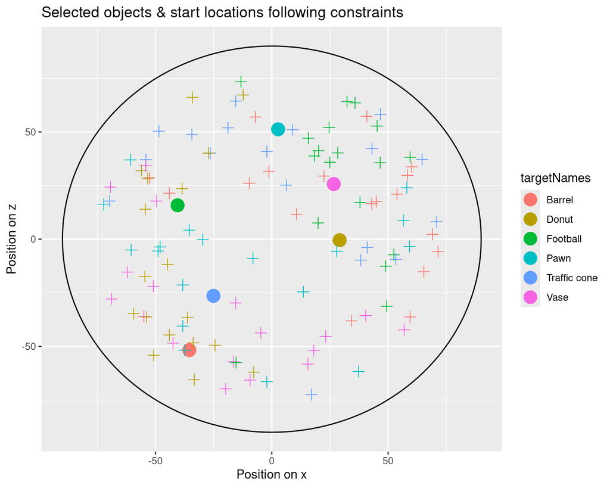

```r
# Plot results
ggplot(trialOrder) +
  geom_point(aes(x = x, y = z, colour = targetNames), size = 5) +
  geom_point(aes(x = start_x, y = start_z, colour = targetNames), size = 3, shape = 3) +
  geom_path(data = edge, mapping = aes(x = x, y = z)) +
  labs(title = "Selected objects & start locations following constraints", x = "Position on x", y = "Position on z")
```

Or plotted for each object separately:

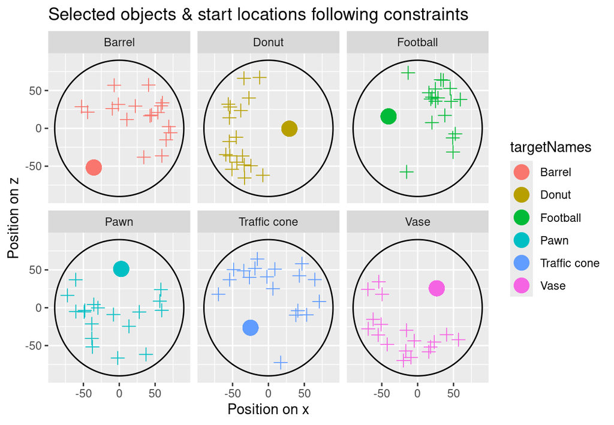

```r
ggplot(trialOrder) +
  facet_wrap(~ targetNames) +
  geom_point(aes(x = x, y = z, colour = targetNames), size = 5) +
  geom_point(aes(x = start_x, y = start_z, colour = targetNames), size = 3, shape = 3) +
  geom_path(data = edge, mapping = aes(x = x, y = z)) +
  labs(title = "Selected objects & start locations following constraints", x = "Position on x", y = "Position on z")
```

```r
# After display put the correct names in for control trials
trialOrder$targets[trialOrder$trialType == 'control'] <- 9
trialOrder$targetNames[trialOrder$trialType == 'control'] <- "Gift"
```

## Calculate translation angles

In order to check a) if the overall distribution of angles are acceptable and to make sure that there are no differences between the three conditions, I quickly calculated the angles of translation if performance were perfect.

```r
# Create column
trialOrder$perfectAngle <- NA

# Loop through each trial
for(i in 1:nrow(trialOrder)){
  # Step 1 get points
  x <- trialOrder$x[i] - trialOrder$start_x[i]
  z <- trialOrder$z[i] - trialOrder$start_z[i]

  # Calculate angle
  trialOrder$perfectAngle[i] <- getAngleInDegreesFromPoint(x, z)
}
```

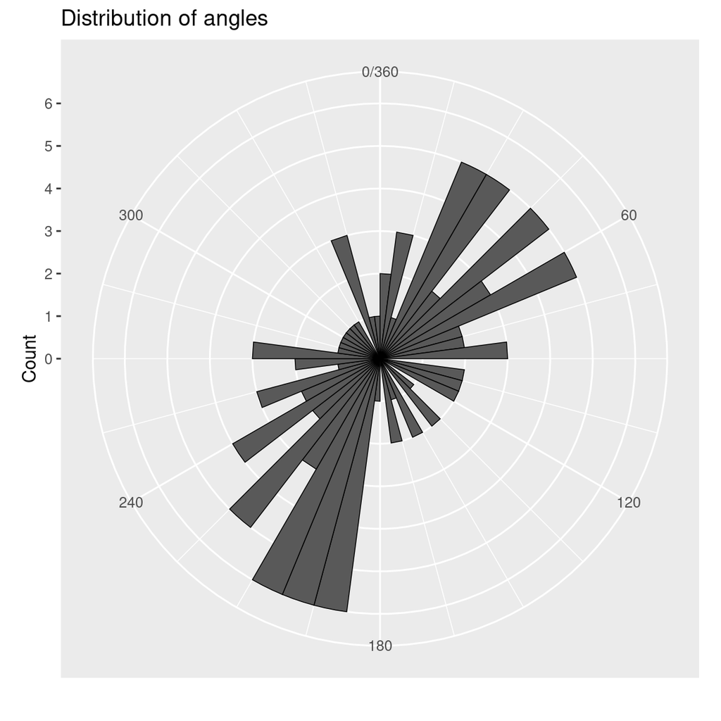

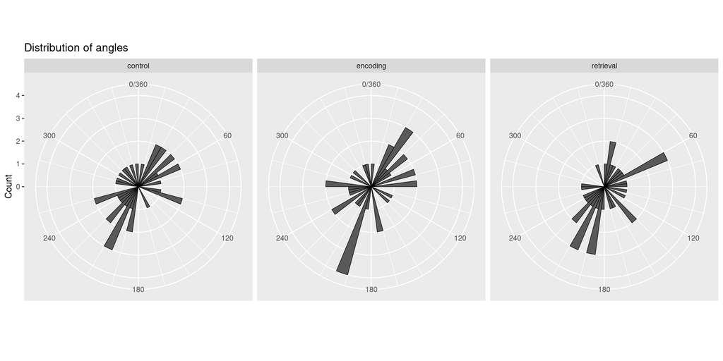

## Calculate centrality

An object is central if it is within the circle that has half the radius of the outer circle (the border of the arena).

```r
# Area of the arena
radius1     <- diameter/2
areaCircle1 <- pi*radius1^2

# Area of the arena with half the radius
radius2 <- radius1/2
areaCircle2 <- pi*radius2^2

areaCentre <- areaCircle2
areaPeriphery <- areaCircle1 - areaCircle2

# Temp bind centre and start locations
tempBind <- rbind(centre, data.frame(x = trialOrder$start_x, z = trialOrder$start_z))

# Calculate distances
distances <- as.matrix(dist(tempBind))[1, 2:nrow(tempBind)]

# Create & assign centrality value
trialOrder$start_centrality <- ifelse(distances >= radius1/2, 'perihery', 'central')
```

# Create the .csv file

```r
# Adding to one DF
mainTask <- data.frame(trial_num = trialOrder$trial_num,
                       block_num = trialOrder$block_num,
                       targets = trialOrder$targets,
                       targetNames= trialOrder$targetNames,
                       start_x = trialOrder$start_x,
                       start_z = trialOrder$start_z,
                       object_x = trialOrder$x,
                       object_z = trialOrder$z,
                       cue = trialOrder$cuePeriod,
                       delay = trialOrder$delayPeriods,
                       ITI = trialOrder$ITIPeriods,
                       trialType = trialOrder$trialType,
                       speedForward = speedForward,
                       rotationSpeed = rotationSpeed,
                       start_centrality = trialOrder$start_centrality,
                       perfectAngle = trialOrder$perfectAngle,
                       messageToDisplay = -1)

# Sample start locations from uniform distribution
mainTask$start_yRotation <- runif(n = nrow(mainTask), min = 0, max = 360)

# Add a messages after the runs
mainTask[(numberPerObject*numObjects), 'messageToDisplay']  <- 0 # Before retrieval/control 1
mainTask[(numberPerObject*numObjects)+(numberPerObject*numObjects)*2, 'messageToDisplay']  <- 1 # Before encoding 2
mainTask[(numberPerObject*numObjects)+(numberPerObject*numObjects)*2+(numberPerObject*numObjects), 'messageToDisplay'] <- 0 # Before retrieval/control 2

# Write .csv file
write.csv(x = mainTask, file = 'inputFiles/2_OLM_fMRI/mainTask_fMRI_version1_session2.csv', quote = FALSE, row.names = FALSE)
```